# Lab 01 R Learning

Jesus W. Avalos Quizhpi

2024-01-13

# Logical Operators:

1. Use logical operations to get R to agree that “two plus two equals 5” is FALSE.

```r
operation <- 2 + 2 == 5
cat("2 + 2 equals 5 is ", operation)
```

```
## 2 + 2 equals 5 is  FALSE
```

2. Use logical operations to test whether 8 ^ 13 is less than 15 ^ 9.

```r
r1 <- 8 ^ 13
r2 <- 15 ^ 9
operation2 <- r1 < r2
cat("8 ^ 13 is less than 15 ^ 9. This is ", operation2)
```

```
## 8 ^ 13 is less than 15 ^ 9. This is  FALSE
```

# Variables:

3. Create a variable called potato whose value corresponds to the number of potatoes you’ve eaten in the last week. Or something equally ridiculous. Print out the value of potato.

```r
potato <- 4 #Number of potatoes eaten in the last week
cat("The number of potatoes I have eaten since last week is: ", potato)
```

```
## The number of potatoes I have eaten since last week is:  4
```

4. Calculate the square root of potato using the sqrt() function. Print out the value of potato again to verify that the value of potato hasn’t changed.

```r
sqrt_potato <- sqrt(potato)
print(potato)
```

```
## [1] 4
```

5. Reassign the value of potato to potato * 2. Print out the new value of potato to verify that it has changed.

```r
potato <- potato * 2
print(potato)
```

```
## [1] 8
```

6. Try making a character (string) variable and a logical variable . Try creating a variable with a “missing” value NA. You can call these variables whatever you would like. Use class(variablename) to make sure they are the right type of variable.

```r
string_var <- "how you doing?"
logical_var <- TRUE
mis_var <- NA

classes <- paste(class(string_var), class(logical_var), class(mis_var), sep = ", ")
cat("Type of variable for string_var, logical_var, and missing_var respectively: ", classes)
```

```
## Type of variable for string_var, logical_var, and missing_var respectively:  character, logical, logical
```

# Vectors:

7. Create a numeric vector with three elements using c().

```r
num_vec <- c(1,3, 5)
cat("the numeric vector is: ", num_vec)
```

```
## the numeric vector is:  1 3 5
```

8. Create a character vector with three elements using c().

```r
vec <- c("element1", "element2", "element3")
vec
```

```
## [1] "element1" "element2" "element3"
```

9. Create a numeric vector called age whose elements contain the ages of three people you know, where the names of each element correspond to the names of those people.

```r
age <- c("Ramon" = 15, "Pedro" = 27, "Brian" = 30)
print(age)
```

```
## Ramon Pedro Brian
##    15    27    30
```

10. Use “indexing by number” to get R to print out the first element of one of the vectors you created in the last questions.

```r
first_num_vec <- num_vec[1]   #Indexation by number
cat("First element of the numeric vector num_vec: ", first_num_vec)
```

```
## First element of the numeric vector num_vec:  1
```

11. Use logical indexing to return all the ages of all people in age greater than 20.

```r
age_over_20 <- age[age > 20]
age_over_20
```

```
## Pedro Brian
##    27    30
```

12. Use indexing by name to return the age of one of the people whose ages you’ve stored in age

```r
age_by_name <- age["Pedro"]
age_by_name
```

```
## Pedro
##    27
```

# Matrices:

# Dataframes:

13. Load the airquality dataset.
14. Use the $ method to print out the Wind variable in airquality.
15. Print out the third element of the Wind variable.

```r
data(airquality) # Load the airquality dataset.
#View(airquality)
wind_var <- airquality$Wind #Use the $ method to print out the Wind variable in airquality.
print(wind_var)
```

```
##   [1]  7.4  8.0 12.6 11.5 14.3 14.9  8.6 13.8 20.1  8.6  6.9  9.7  9.2 10.9 13.2
##  [16] 11.5 12.0 18.4 11.5  9.7  9.7 16.6  9.7 12.0 16.6 14.9  8.0 12.0 14.9  5.7
##  [31]  7.4  8.6  9.7 16.1  9.2  8.6 14.3  9.7  6.9 13.8 11.5 10.9  9.2  8.0 13.8
##  [46] 11.5 14.9 20.7  9.2 11.5 10.3  6.3  1.7  4.6  6.3  8.0  8.0 10.3 11.5 14.9
##  [61]  8.0  4.1  9.2  9.2 10.9  4.6 10.9  5.1  6.3  5.7  7.4  8.6 14.3 14.9 14.9
##  [76] 14.3  6.9 10.3  6.3  5.1 11.5  6.9  9.7 11.5  8.6  8.0  8.6 12.0  7.4  7.4
##  [91]  7.4  9.2  6.9 13.8  7.4  6.9  7.4  4.6  4.0 10.3  8.0  8.6 11.5 11.5 11.5
## [106]  9.7 11.5 10.3  6.3  7.4 10.9 10.3 15.5 14.3 12.6  9.7  3.4  8.0  5.7  9.7
## [121]  2.3  6.3  6.3  6.9  5.1  2.8  4.6  7.4 15.5 10.9 10.3 10.9  9.7 14.9 15.5
## [136]  6.3 10.9 11.5  6.9 13.8 10.3 10.3  8.0 12.6  9.2 10.3 10.3 16.6  6.9 13.2
## [151] 14.3  8.0 11.5
```

```r
cat("The third element of the Wind variable is: ",wind_var[3]) #Print out the third element of the Wind variable.
```

```
## The third element of the Wind variable is:  12.6
```

16. Create a new data frame called aq that includes only the first 10 cases. Hint: typing c(1,2,3,4,5,6,7,8,9,10) is tedious. R allows you to use 1:10 as a shorthand method!
17. Use logical indexing to print out all days (ie. cases) in aq where the Ozone level was higher than 20.
    1. What did the output do with NA values?
18. Use subset() to do the same thing. Notice the difference in the output.

```r
#q16
aq <- airquality[1:10, ]
print("First 10 cases of the dataset airquality:")
```

```
## [1] "First 10 cases of the dataset airquality:"
```

```r
print(aq)
```

```
##    Ozone Solar.R Wind Temp Month Day
## 1     41     190  7.4   67     5   1
## 2     36     118  8.0   72     5   2
## 3     12     149 12.6   74     5   3
## 4     18     313 11.5   62     5   4
## 5     NA      NA 14.3   56     5   5
## 6     28      NA 14.9   66     5   6
## 7     23     299  8.6   65     5   7
## 8     19      99 13.8   59     5   8
## 9      8      19 20.1   61     5   9
## 10    NA     194  8.6   69     5  10
```

```r
#q17
aq_ozone_over20 <- aq$Day[aq$Ozone>20]
print(aq_ozone_over20)
```

```
## [1]  1  2 NA  6  7 NA
```

*Response for 17q a): We see on the result that NAs in the Ozone column are considered for the output. To correct this, we use subset for q18 to see how the result change:*

```r
#q18
aq_ozone_morethan20 <- subset(aq, Ozone > 20)
print(aq_ozone_morethan20)
```

```
##   Ozone Solar.R Wind Temp Month Day
## 1    41     190  7.4   67     5   1
## 2    36     118  8.0   72     5   2
## 6    28      NA 14.9   66     5   6
## 7    23     299  8.6   65     5   7
```

*Analysis: Using function subset(), it does not consider NAs in the Ozone column.*

19. Create a TooWindy variable inside aq, which is a logical variable that is TRUE if Wind is greater than 10, and FALSE otherwise.

```r
aq$TooWindy <- aq$Wind > 10
print(aq[c("Day", "TooWindy")])
```

```
##    Day TooWindy
## 1    1    FALSE
## 2    2    FALSE
## 3    3     TRUE
## 4    4     TRUE
## 5    5     TRUE
## 6    6     TRUE
## 7    7    FALSE
## 8    8     TRUE
## 9    9     TRUE
## 10  10    FALSE
```

20. Use the length() function to determine the number of observations in the airquality dataframe.

```r
length(airquality$Day)
```

```
## [1] 153
```

```r
nrow(airquality) #We could better use function nrow()
```

```
## [1] 153
```

21. Calculate the mean and standard deviation of one of the variables in airquality.

```r
wind_mean <- mean(airquality$Wind)
wind_sd <- sd(airquality$Wind)
print(c("Mean for variable Wind: " = wind_mean, "Standard deviation for variable Wind: " = wind_sd))
```

```
##               Mean for variable Wind:  Standard deviation for variable Wind:
##                               9.957516                               3.523001
```

22. Make a table of the Temp values.

```r
temp <- table(airquality$Temp)
knitr::kable(temp) #A better way to view a table through the knitr package
```

| Var1 | Freq |
| --- | --- |
| 56 | 1 |
| 57 | 3 |
| 58 | 2 |
| 59 | 2 |
| 61 | 3 |
| 62 | 2 |
| 63 | 1 |
| 64 | 2 |
| 65 | 2 |
| 66 | 3 |
| 67 | 4 |
| 68 | 4 |
| 69 | 3 |
| 70 | 1 |
| 71 | 3 |
| 72 | 3 |
| 73 | 5 |
| 74 | 4 |
| 75 | 4 |
| 76 | 9 |
| 77 | 7 |
| 78 | 6 |
| 79 | 6 |
| 80 | 5 |
| 81 | 11 |
| 82 | 9 |
| 83 | 4 |
| 84 | 5 |
| 85 | 5 |
| 86 | 7 |
| 87 | 5 |
| 88 | 3 |
| 89 | 2 |
| 90 | 3 |
| 91 | 2 |
| 92 | 5 |
| 93 | 3 |
| 94 | 2 |
| 96 | 1 |
| 97 | 1 |

23. Make a histogram of the Ozone column. Is it a normal distribution? Why or why not?

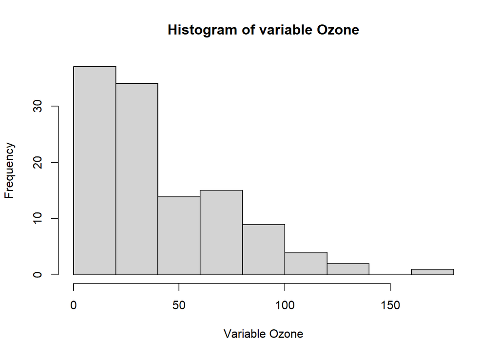

```r
hist(airquality$Ozone, main = "Histogram of variable Ozone", xlab = "Variable Ozone")
```

*Based on the histogram only, we can notice that it does not show a normal distribution. We may conclude that the variable does not follow a normal distribution. We should run a shapiro test to statisticlly confirm this hypothesis.*

```r
print(shapiro.test(airquality$Ozone))
```

```
##
##  Shapiro-Wilk normality test
##
## data:  airquality$Ozone
## W = 0.87867, p-value = 2.79e-08
```

*The p-value is quite small (very close to 0), therefore, we have statistical evidence to reject the null hypotesis. In other words, we have statistical evidence to say that the variable Ozone does not follow a normal distribution.*

# Functions:

24. Make a simple function to calculate x + 6.

```r
funct <- function(x) {
  x + 6
}
cat("The result of the function if x = 23 is: ", funct(23))
```

```
## The result of the function if x = 23 is:  29
```

25. Use that function add 6 to the Temp column in airquality.

```r
airquality$Temp_plus6 <- funct(airquality$Temp)
head(airquality)
```

```
##   Ozone Solar.R Wind Temp Month Day Temp_plus6
## 1    41     190  7.4   67     5   1         73
## 2    36     118  8.0   72     5   2         78
## 3    12     149 12.6   74     5   3         80
## 4    18     313 11.5   62     5   4         68
## 5    NA      NA 14.3   56     5   5         62
## 6    28      NA 14.9   66     5   6         72
```

# Packages:

26. Install the ggplot2 package.
27. Install the car package.
28. Install the ez package. (no output necessary for these three)
29. Load the car library.

```r
options(repos = c(CRAN = "https://cloud.r-project.org"))
install.packages("ggplot2") #q26
install.packages("car") #q27
install.packages("ez") #q28
library(car) #q29
```

# Files

30. Import the csv file provided on Canvas.

```r
csv_file <- read.csv("lab_R_learning.csv")
print(csv_file)
```

```
##    variable1 stuff2 thing3
## 1          3 cheese   TRUE
## 2          4   feta  FALSE
## 3          6  swiss   TRUE
## 4          4 cheese  FALSE
## 5          7   feta  FALSE
## 6          2  swiss   TRUE
## 7          8 cheese  FALSE
## 8          9   feta  FALSE
## 9          3  swiss   TRUE
## 10         4         FALSE
```